# Turkey Migration Map

R-Boys

30 November 2018

## Getting Source Files

We are going to use TUIK data for our main analysis. Original excel file can be found in this [link.](http://www.tuik.gov.tr/PreIstatistikTablo.do?istab_id=2620)

## Downloading & Reading from excel

```r
# I will skip first three lines by skip function and then slice the last 3 lines afterwards
maindata <- readxl::read_excel("D:/Data Analytics Esentials/project/domestic_migration_inflow&outflow.xls",skip=3) %>%
  slice(-c(329:333))
# Let's see if it look ok or not
head(maindata)
```

```
## # A tibble: 6 x 86
##   Yil   Alan  Toplam Adana `Adiyaman` Afyonkarahisar `Agri` Amasya Ankara
##   <chr> <chr>  <dbl> <dbl>      <dbl>          <dbl>  <dbl>  <dbl>  <dbl>
## 1 2017  Topl~ 2.68e6 78422      34453          28264  40965  18889 121902
## 2 2017  Adana 4.95e4 21992        785             82    184     61    827
## 3 2017  Adiy~ 1.80e4   460       9448             21     57     12    208
## 4 2017  Afyo~ 2.15e4   271        100           7301    143     68    943
## 5 2017  Agri  1.51e4   183        115            112   6201     63    427
## 6 2017  Amas~ 1.43e4   135         72             34     95   5079    565
## # ... with 77 more variables: Antalya <dbl>, Artvin <dbl>, `Aydin` <dbl>,
## #   `Balikesir` <dbl>, Bilecik <dbl>, Bingöl <dbl>, Bitlis <dbl>,
## #   Bolu <dbl>, Burdur <dbl>, Bursa <dbl>, Çanakkale <dbl>,
## #   `Çankiri` <dbl>, Çorum <dbl>, Denizli <dbl>, `Diyarbakir` <dbl>,
## #   Edirne <dbl>, `Elazig` <dbl>, Erzincan <dbl>, Erzurum <dbl>,
## #   `Eskisehir` <dbl>, Gaziantep <dbl>, Giresun <dbl>, `Gümüshane` <dbl>,
## #   Hakkari <dbl>, Hatay <dbl>, Isparta <dbl>, Mersin <dbl>,
## #   `Istanbul` <dbl>, `Izmir` <dbl>, Kars <dbl>, Kastamonu <dbl>,
## #   Kayseri <dbl>, `Kirklareli` <chr>, `Kirsehir` <dbl>, Kocaeli <dbl>,
## #   Konya <dbl>, Kütahya <dbl>, Malatya <dbl>, Manisa <dbl>,
## #   `Kahramanmaras` <dbl>, Mardin <dbl>, `Mugla` <dbl>, `Mus` <dbl>,
## #   `Nevsehir` <dbl>, `Nigde` <dbl>, Ordu <dbl>, Rize <dbl>,
## #   Sakarya <dbl>, Samsun <dbl>, Siirt <dbl>, Sinop <dbl>, Sivas <dbl>,
## #   `Tekirdag` <dbl>, Tokat <dbl>, Trabzon <dbl>, Tunceli <chr>,
## #   `Sanliurfa` <dbl>, `Usak` <dbl>, Van <dbl>, Yozgat <dbl>,
## #   Zonguldak <dbl>, Aksaray <dbl>, Bayburt <dbl>, Karaman <dbl>,
## #   `Kirikkale` <dbl>, Batman <dbl>, `Sirnak` <dbl>, `Bartin` <dbl>,
## #   Ardahan <dbl>, `Igdir` <dbl>, Yalova <chr>, Karabük <dbl>,
## #   Kilis <chr>, Osmaniye <dbl>, Düzce <dbl>, `Yurt disi\nAbroad` <dbl>,
## #   `Bilinmeyen\nUnknown` <dbl>
```

## Re-shaping the data

Since the file we have structured in a horizontal way it is better to transform it to a more vertical way by using melt function

```r
# I will melt the data by the the columns Yil, Alan and Toplam
melted_data <- melt(maindata, id.vars = c("Yil", "Alan", "Toplam"))
# Let's check again
head(melted_data)
```

```
##    Yil           Alan  Toplam variable value
## 1 2017   Toplam-Total 2684820    Adana 78422
## 2 2017          Adana   49509    Adana 21992
## 3 2017       Adiyaman   18040    Adana   460
## 4 2017 Afyonkarahisar   21453    Adana   271
## 5 2017           Agri   15088    Adana   183
## 6 2017         Amasya   14326    Adana   135
```

## Next step is eliminating a few unnecessary information

Here we go

```r
clean_data <- melted_data %>%
# We would not need total lines, we can calculate it anytime we want
  filter(Alan != "Toplam-Total") %>%
# We need only the period information, and cities both departure and destination also the number of people migrated
  select(Yil, Alan, variable, value) %>%
  arrange(Yil, Alan, variable, value)
# We can define better column names and data types
colnames(clean_data) <- c("Year", "Destination", "Departure", "People")
clean_data$Year <- as.integer(clean_data$Year)
suppressWarnings(clean_data$`People` <- as.integer(clean_data$`People`))
clean_data$Departure <- as.character(clean_data$Departure)
# Did you remember the error when we first read from excel? It time to fix it
clean_data$Destination <- enc2native(clean_data$Destination)
clean_data$Departure <- enc2native(clean_data$Departure)
# Final checks
head(clean_data)
```

[output not shown]

```
##   Year Destination      Departure People
## 1 2014       Adana          Adana  20638
## 2 2014       Adana       Adiyaman   1009
## 3 2014       Adana Afyonkarahisar     84
## 4 2014       Adana           Agri    184
## 5 2014       Adana         Amasya     63
## 6 2014       Adana         Ankara    868
```

## Now the critical part: Translation from TR to EN

Our excel file was an ASCII encoded file including TR language character. Unfortunately those are the obsticables to almost anything. We need to convert them in order to get a proper data set. Let’s start by defining a procedure for it

```r
mgsub <- function(pattern, replacement, x, ...) {
  n = length(pattern)
  if (n != length(replacement)) {
    stop("pattern and replacement do not have the same length.")
  }
  result = x
  for (i in 1:n) {
    result <- gsub(pattern[i],replacement[i],result)
  }
  return(result)
}

tr_to_en <- function(datafile){
  turkish_letters <- c("Ã","Å","Ä","Ä°","Ã","Ã","Ã§","Å","Ä","Ä±","Ã¼","Ã¶")
  english_letters <- c("C","S","G","I","U","O","c","s","g","i","u","o")
  datafile <- mgsub(turkish_letters,english_letters,datafile)
  return(datafile)
}
```

When we execute above procedure it will convert TR characters from our data set to EN

```r
clean_data$Departure <- tr_to_en(clean_data$Departure)
clean_data$Destination <- tr_to_en(clean_data$Destination)
```

## We came so far let’s save it

```r
saveRDS(clean_data, file = "D:/Data Analytics Esentials/project/clean_migration.rds")
```

# We prefer to show numbers on a map: Then we need a Turkey map

First we need to go to [this](https://gadm.org/download_country_v3.html) web page to download Turkey political map. It is only for non commercial use. First we need to select Turkey and then select R (SpatialPolygonsDataFrame) with level 1 information which only includes cities (Level 2 would also include towns).

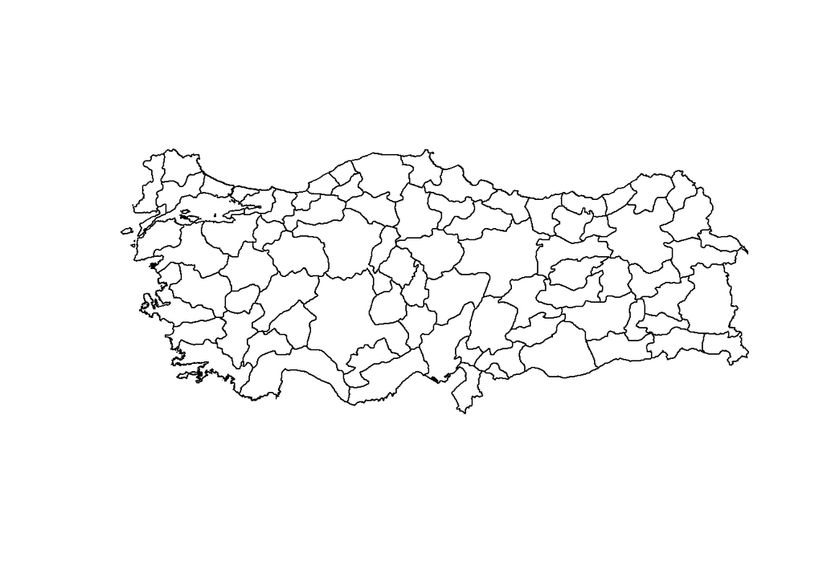

```r
# We need sp library for the map
library(sp)
# Let's assign it to a variable
TRmap <- readRDS("D:/Data Analytics Esentials/project/gadm36_TUR_1_sp.rds")
# We need to do one more convertion in order to match two data set
TRmap@data$NAME_1 <- tr_to_en(TRmap@data$NAME_1)
TRmap@data$NAME_1 <- gsub("K. Maras", "Kahramanmaras",TRmap@data$NAME_1)
TRmap@data$NAME_1 <- gsub("Kinkkale","Kirikkale",TRmap@data$NAME_1)
TRmap@data$NAME_1 <- gsub("Zinguldak", "Zonguldak", TRmap@data$NAME_1)
TRmap@data$NAME_1 <- gsub("Afyon","Afyonkarahisar", TRmap@data$NAME_1)
TRmap@data$NAME_1 <- enc2native(gsub("BartÄ±n","Bartin", TRmap@data$NAME_1))
TRmap@data$NAME_1 <- enc2native(gsub("ElazÄ±Ä","Elazig", TRmap@data$NAME_1))
TRmap@data$NAME_1 <- enc2native(gsub("IÄdÄ±r","Igdir", TRmap@data$NAME_1))
# plot function will allow us to see the basic map
plot(TRmap)
```

## Let’s intruduce it to ggplot

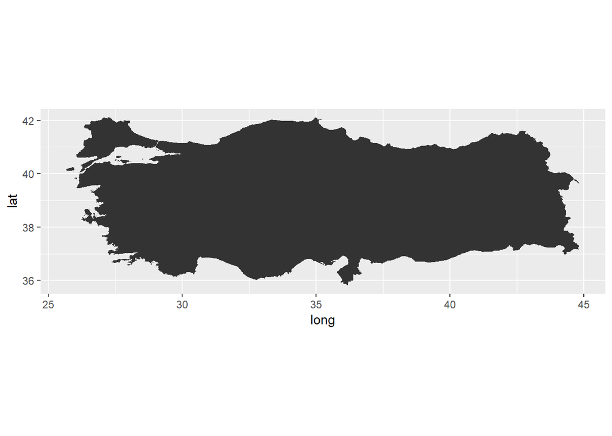

```r
ggplot(TRmap, aes(x = long, y = lat)) +
  geom_polygon(aes(group = group)) +
  coord_fixed()
```

## Next step is to define cities

We should use fortify function from sp library

```r
TRcity <- fortify(TRmap)
```

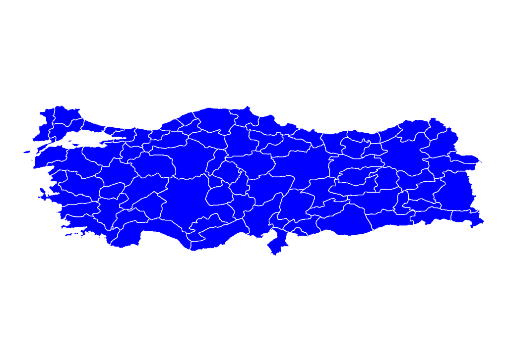

```r
# Let's update ggplot a little bit
ggplot(TRcity) +
  geom_polygon(aes(x = long, y = lat, group = group), color = "white", fill = "blue") +
  theme_void() +
  coord_fixed()
```

## For years Istanbul is the most populated and most migrated city of Turkey

Now we have necessary tools to demonstrate where people come to Istanbul in last 4 year. Let’s start by most recent one; 2017

```r
ist17 <- clean_data %>%
  filter(Year == 2017, Destination == "Istanbul")

head(ist17)
```

```
##   Year Destination      Departure People
## 1 2017    Istanbul          Adana   7242
## 2 2017    Istanbul       Adiyaman   4956
## 3 2017    Istanbul Afyonkarahisar   1760
## 4 2017    Istanbul           Agri   7723
## 5 2017    Istanbul         Amasya   2685
## 6 2017    Istanbul         Ankara  10613
```

## Communication of tables by join

We are going to use left join to match them

```r
mig_ist <- data_frame(id = rownames(TRmap@data), Departure = TRmap@data$NAME_1) %>%
  left_join(ist17, by = "Departure")

mig_ist_map <- left_join(TRcity, mig_ist, by = "id")
```

## Finally we are ready to see the end product

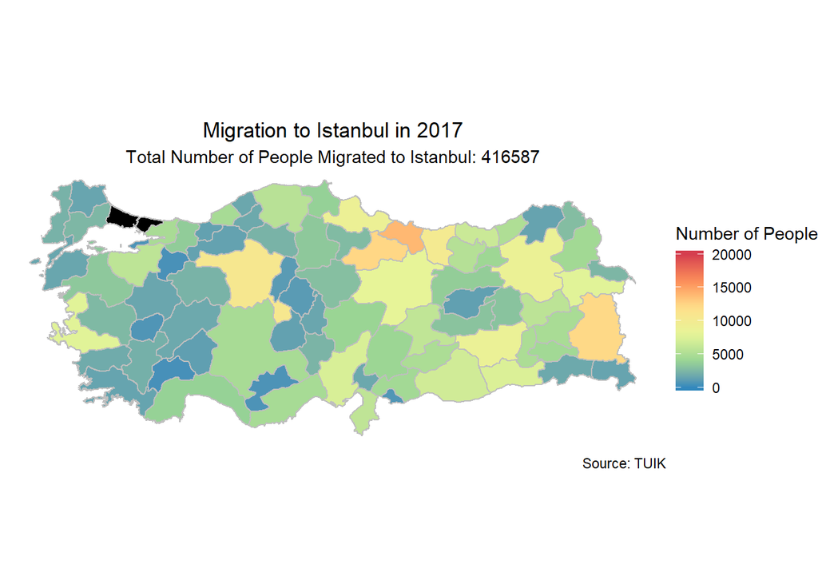

```r
ggplot(mig_ist_map) +
  geom_polygon( aes(x = long, y = lat, group = group, fill = People), color = "grey") +
  coord_map() + theme_void() +
  labs(title = "Migration to Istanbul in 2017", subtitle = paste0("Total Number of People Migrated to Istanbul: ", sum(ist17$People)), caption = "Source: TUIK") +
  scale_fill_distiller(name = "Number of People", palette = "Spectral", limits = c(0,20000), na.value = "black") + theme(plot.title = element_text(hjust = 0.5), plot.subtitle = element_text(hjust = 0.5))
```